# Introduction to Bioconductor Annotation Resources

12-16 June | CSAMA 2023

## What is annotation data?

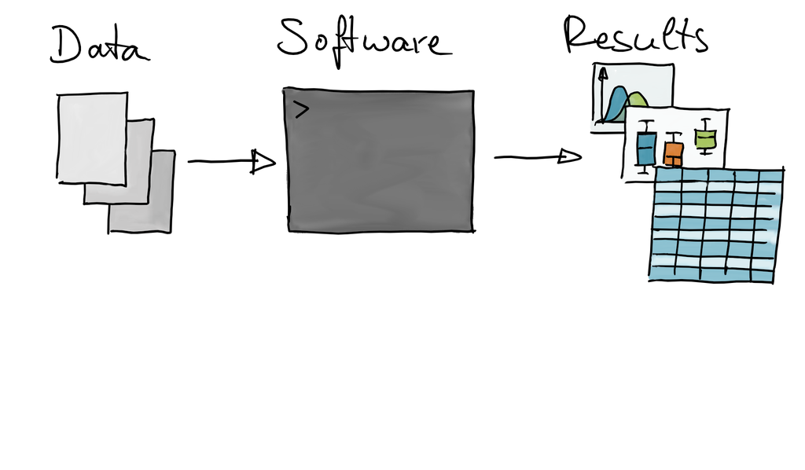

## What is annotation data?

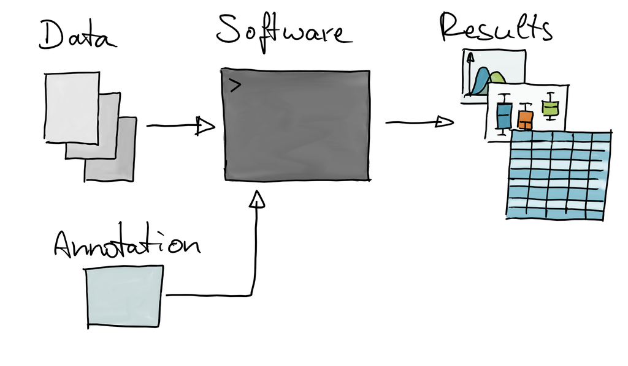

- Annotation data: usually external data that is used to *make sense* of measured entities.

## What do we mean by annotation?

Map a known ID to other functional or positional information

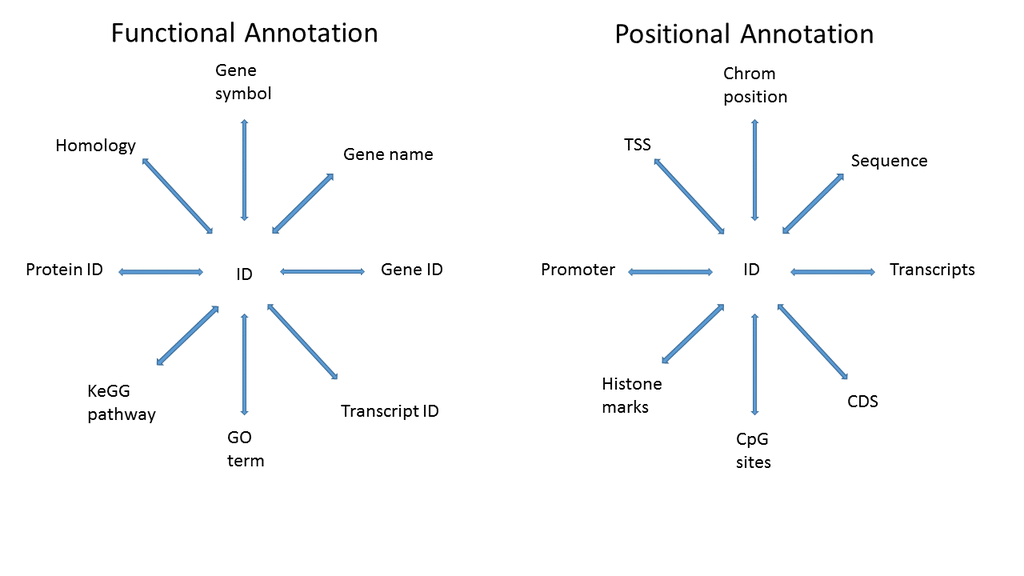

- Map one type of ID to another type of ID that is more familiar to collaborators or perhaps better used for further analysis or reporting.

## Typical annotation use cases

- get HUGO gene symbols for gene identifiers (e.g. Entrezgene, Ensembl…).
- map positions on the genome to transcripts (genes).
- map genes to biological pathways.
- assign peptide sequences to proteins.
- identify metabolites based on fragment spectra.

**Annotation**: map one type of ID to another type of ID.

## Annotation resources

- NCBI: https://www.ncbi.nlm.nih.gov/
- Ensembl: http://www.ensembl.org/index.html
- Uniprot: https://www.uniprot.org/
- Pubchem: https://pubchem.ncbi.nlm.nih.gov/
- Reactome: https://reactome.org/
- …

Can be downloaded or queried through an API.

## Annotation resources in **Bioconductor**

- Annotation packages:
  - *org.Hs.eg.db*
  - *BSgenome.Hsapiens.UCSC.hg19*
  - *TxDb.Hsapiens.UCSC.hg19.knownGene*
  - *GO.db*
  - …
- *AnnotationHub*: query and retrieve annotations, cache them locally.
- Online resources: *biomaRt*, *KEGGREST*.
- Direct access to web resources through an API (be sure to BiocFileCache!)

## Annotation packages in Bioconductor

- *org.Hs.eg.db*: package with various annotations for homo sapiens.

```r
BiocManager::install("org.Hs.eg.db")
library(org.Hs.eg.db)
org.Hs.eg.db
```

```
## OrgDb object:
## | DBSCHEMAVERSION: 2.1
## | Db type: OrgDb
## | Supporting package: AnnotationDbi
## | DBSCHEMA: HUMAN_DB
## | ORGANISM: Homo sapiens
## | SPECIES: Human
## | EGSOURCEDATE: 2023-Mar05
## | EGSOURCENAME: Entrez Gene
## | EGSOURCEURL: ftp://ftp.ncbi.nlm.nih.gov/gene/DATA
## | CENTRALID: EG
## | TAXID: 9606
## | GOSOURCENAME: Gene Ontology
## | GOSOURCEURL: http://current.geneontology.org/ontology/go-basic.obo
## | GOSOURCEDATE: 2023-01-01
## | GOEGSOURCEDATE: 2023-Mar05
## | GOEGSOURCENAME: Entrez Gene
## | GOEGSOURCEURL: ftp://ftp.ncbi.nlm.nih.gov/gene/DATA
## | KEGGSOURCENAME: KEGG GENOME
## | KEGGSOURCEURL: ftp://ftp.genome.jp/pub/kegg/genomes
## | KEGGSOURCEDATE: 2011-Mar15
## | GPSOURCENAME: UCSC Genome Bioinformatics (Homo sapiens)
## | GPSOURCEURL:
## | GPSOURCEDATE: 2023-Feb8
## | ENSOURCEDATE: 2023-Feb10
## | ENSOURCENAME: Ensembl
## | ENSOURCEURL: ftp://ftp.ensembl.org/pub/current_fasta
## | UPSOURCENAME: Uniprot
## | UPSOURCEURL: http://www.UniProt.org/
## | UPSOURCEDATE: Wed Mar 15 15:58:07 2023
```

**How can we get access to the data in a Bioconductor annotation resource?**

### **A common annotation interface:** *AnnotationDbi*

The main function is `select`:

AnnotationDbi::select(*anno*, *keys*, *columns*, *keytype*)

Where

- *anno* is the annotation package (or object)
- *keys* are the IDs that we **have**
- *columns* are the values we **want**
- *keytype* is the type of key used

## Simple Example

- *Task*: annotate gene identifiers to HUGO symbols.
- The *airway* package provides a `RangedSummarizedExperiment` with results from an RNA-Seq experiment.
- Genes are identified by their Ensembl IDs.

```r
library(airway)
data(airway)
ids <- head(rownames(airway))
ids
```

```
## [1] "ENSG00000000003" "ENSG00000000005" "ENSG00000000419" "ENSG00000000457"
## [5] "ENSG00000000460" "ENSG00000000938"
```

```r
select(org.Hs.eg.db, ids, "SYMBOL", "ENSEMBL")
```

```
##           ENSEMBL SYMBOL
## 1 ENSG00000000003 TSPAN6
## 2 ENSG00000000005   TNMD
## 3 ENSG00000000419   DPM1
## 4 ENSG00000000457  SCYL3
## 5 ENSG00000000460  FIRRM
## 6 ENSG00000000938    FGR
```

## What annotations are provided?

- Use `columns` to list annotations available in specific annotation object.

```r
columns(org.Hs.eg.db)
```

```
##  [1] "ACCNUM"       "ALIAS"        "ENSEMBL"      "ENSEMBLPROT"  "ENSEMBLTRANS"
##  [6] "ENTREZID"     "ENZYME"       "EVIDENCE"     "EVIDENCEALL"  "GENENAME"
## [11] "GENETYPE"     "GO"           "GOALL"        "IPI"          "MAP"
## [16] "OMIM"         "ONTOLOGY"     "ONTOLOGYALL"  "PATH"         "PFAM"
## [21] "PMID"         "PROSITE"      "REFSEQ"       "SYMBOL"       "UCSCKG"
## [26] "UNIPROT"
```

- Use `keytypes` to list supported *key types*.

```r
keytypes(org.Hs.eg.db)
```

```
##  [1] "ACCNUM"       "ALIAS"        "ENSEMBL"      "ENSEMBLPROT"  "ENSEMBLTRANS"
##  [6] "ENTREZID"     "ENZYME"       "EVIDENCE"     "EVIDENCEALL"  "GENENAME"
## [11] "GENETYPE"     "GO"           "GOALL"        "IPI"          "MAP"
## [16] "OMIM"         "ONTOLOGY"     "ONTOLOGYALL"  "PATH"         "PFAM"
## [21] "PMID"         "PROSITE"      "REFSEQ"       "SYMBOL"       "UCSCKG"
## [26] "UNIPROT"
```

## Another example

- Get OMIM IDs for two genes.

```r
brca <- c("BRCA1", "BRCA2")
select(org.Hs.eg.db, brca, c("GENENAME", "OMIM"), "SYMBOL")
```

```
##    SYMBOL                    GENENAME   OMIM
## 1   BRCA1 BRCA1 DNA repair associated 113705
## 2   BRCA1 BRCA1 DNA repair associated 114480
## 3   BRCA1 BRCA1 DNA repair associated 604370
## 4   BRCA1 BRCA1 DNA repair associated 614320
## 5   BRCA1 BRCA1 DNA repair associated 617883
## 6   BRCA2 BRCA2 DNA repair associated 114480
## 7   BRCA2 BRCA2 DNA repair associated 155255
## 8   BRCA2 BRCA2 DNA repair associated 176807
## 9   BRCA2 BRCA2 DNA repair associated 194070
## 10  BRCA2 BRCA2 DNA repair associated 600185
## 11  BRCA2 BRCA2 DNA repair associated 605724
## 12  BRCA2 BRCA2 DNA repair associated 612555
## 13  BRCA2 BRCA2 DNA repair associated 613029
## 14  BRCA2 BRCA2 DNA repair associated 613347
```

- We no longer have a 1:1 mapping!

## Alternative: the `mapIds` function

- Same as `select` (but for single annotations!).
- Parameter `multiVals` allows to specify how to deal with 1:many mappings.

```r
mapIds(org.Hs.eg.db, brca, "OMIM", "SYMBOL", multiVals = "first")
```

```
##    BRCA1    BRCA2
## "113705" "114480"
```

- OK, but where’s the rest?

## Choices for `multiVals`

- `multiVals = "first"` (default): take the first element.
- `multiVals = "asNA"`: `NA` is returned for any 1:many mapping.
- `multiVals = "list"`: multiple elements are collapsed into a `list`.
- `multiVals = "CharacterList"`: results are returned as a `CharacterList`.

```r
mapIds(org.Hs.eg.db, brca, "OMIM", "SYMBOL", multiVals = "CharacterList")
```

```
## CharacterList of length 2
## [["BRCA1"]] 113705 114480 604370 614320 617883
## [["BRCA2"]] 114480 155255 176807 194070 600185 605724 612555 613029 613347
```

## But…

- *AnnotationDbi* is a very powerful framework, but:
- For some annotations or queries different approaches might be more suitable.
- Not guaranteed that all annotation packages/objects support the *AnnotationDbi* framework.

## What about positional annotation?

- Annotation for positions on the genome (exons, transcripts, genes).
- Annotation for positions along protein sequences (protein domains…).
- Mostly used for gene quantification in RNA-seq data.

### Positional annotations: `TxDb` and `EnsDb` objects

- `TxDb` (*GenomicFeatures* package) and `EnsDb` (*ensembldb* package) objects contain positional annotations.
- `EnsDb` contain additional annotations such as gene symbols, Entrezgene IDs, GC content, gene/transcript biotypes and protein annotations.
- `TxDb` and `EnsDb` resources can be installed as packages (e.g. *TxDb.Hsapiens.UCSC.hg19.knownGene*, *EnsDb.Hsapiens.v86*).
- Preferred way: through *AnnotationHub*.
- **Why?**
  - Provides annotation databases for all species, all Ensembl releases.
  - Guarantees reproducibility.

## Query *AnnotationHub*

- Search annotation resource for a specific species and release.

```r
library(AnnotationHub)
ah <- AnnotationHub()
query(ah, c("EnsDb", "hsapiens", "102"))
```

```
## AnnotationHub with 1 record
## # snapshotDate(): 2023-05-15
## # names(): AH89180
## # $dataprovider: Ensembl
## # $species: Homo sapiens
## # $rdataclass: EnsDb
## # $rdatadateadded: 2020-10-27
## # $title: Ensembl 102 EnsDb for Homo sapiens
## # $description: Gene and protein annotations for Homo sapiens based on Ensem...
## # $taxonomyid: 9606
## # $genome: GRCh38
## # $sourcetype: ensembl
## # $sourceurl: http://www.ensembl.org
## # $sourcesize: NA
## # $tags: c("102", "AHEnsDbs", "Annotation", "EnsDb", "Ensembl", "Gene",
## #   "Protein", "Transcript")
## # retrieve record with 'object[["AH89180"]]'
```

## Fetch from *AnnotationHub*

- Download and cache this annotation.

```r
edb <- ah[["AH89180"]]
edb
```

```
## EnsDb for Ensembl:
## |Backend: SQLite
## |Db type: EnsDb
## |Type of Gene ID: Ensembl Gene ID
## |Supporting package: ensembldb
## |Db created by: ensembldb package from Bioconductor
## |script_version: 0.3.6
## |Creation time: Sat Dec 19 21:24:06 2020
## |ensembl_version: 102
## |ensembl_host: localhost
## |Organism: Homo sapiens
## |taxonomy_id: 9606
## |genome_build: GRCh38
## |DBSCHEMAVERSION: 2.1
## | No. of genes: 68001.
## | No. of transcripts: 254853.
## |Protein data available.
```

## Extract annotations from an `EnsDb` or `TxDb`

- Using *AnnotationDbi*:

```r
columns(edb)
```

```
##  [1] "CANONICALTRANSCRIPT" "DESCRIPTION"         "ENTREZID"
##  [4] "EXONID"              "EXONIDX"             "EXONSEQEND"
##  [7] "EXONSEQSTART"        "GCCONTENT"           "GENEBIOTYPE"
## [10] "GENEID"              "GENEIDVERSION"       "GENENAME"
## [13] "GENESEQEND"          "GENESEQSTART"        "INTERPROACCESSION"
## [16] "ISCIRCULAR"          "PROTDOMEND"          "PROTDOMSTART"
## [19] "PROTEINDOMAINID"     "PROTEINDOMAINSOURCE" "PROTEINID"
## [22] "PROTEINSEQUENCE"     "SEQCOORDSYSTEM"      "SEQLENGTH"
## [25] "SEQNAME"             "SEQSTRAND"           "SYMBOL"
## [28] "TXBIOTYPE"           "TXCDSSEQEND"         "TXCDSSEQSTART"
## [31] "TXID"                "TXIDVERSION"         "TXNAME"
## [34] "TXSEQEND"            "TXSEQSTART"          "TXSUPPORTLEVEL"
## [37] "UNIPROTDB"           "UNIPROTID"           "UNIPROTMAPPINGTYPE"
```

```r
select(edb, "ENSG00000139618",
       c("SYMBOL", "SEQNAME"), "GENEID")
```

```
##            GENEID SYMBOL SEQNAME
## 1 ENSG00000139618  BRCA2      13
```

## Extract positional annototations

- `genes`, `transcripts`,`exons` to extract their genomic coordinates.
- Result returned as `GRanges` object (with additional *metadata columns*).

```r
genes(edb)
```

```
## GRanges object with 68001 ranges and 9 metadata columns:
##                   seqnames            ranges strand |         gene_id
##                      <Rle>         <IRanges>  <Rle> |     <character>
##   ENSG00000223972        1       11869-14409      + | ENSG00000223972
##   ENSG00000227232        1       14404-29570      - | ENSG00000227232
##   ENSG00000278267        1       17369-17436      - | ENSG00000278267
##   ENSG00000243485        1       29554-31109      + | ENSG00000243485
##   ENSG00000284332        1       30366-30503      + | ENSG00000284332
##               ...      ...               ...    ... .             ...
##   ENSG00000224240        Y 26549425-26549743      + | ENSG00000224240
##   ENSG00000227629        Y 26586642-26591601      - | ENSG00000227629
##   ENSG00000237917        Y 26594851-26634652      - | ENSG00000237917
##   ENSG00000231514        Y 26626520-26627159      - | ENSG00000231514
##   ENSG00000235857        Y 56855244-56855488      + | ENSG00000235857
##                     gene_name           gene_biotype seq_coord_system
##                   <character>            <character>      <character>
##   ENSG00000223972     DDX11L1 transcribed_unproces..       chromosome
##   ENSG00000227232      WASH7P unprocessed_pseudogene       chromosome
##   ENSG00000278267   MIR6859-1                  miRNA       chromosome
##   ENSG00000243485 MIR1302-2HG                 lncRNA       chromosome
##   ENSG00000284332   MIR1302-2                  miRNA       chromosome
##               ...         ...                    ...              ...
##   ENSG00000224240     CYCSP49   processed_pseudogene       chromosome
##   ENSG00000227629  SLC25A15P1 unprocessed_pseudogene       chromosome
##   ENSG00000237917     PARP4P1 unprocessed_pseudogene       chromosome
##   ENSG00000231514      CCNQP2   processed_pseudogene       chromosome
##   ENSG00000235857     CTBP2P1   processed_pseudogene       chromosome
##                              description   gene_id_version canonical_transcript
##                              <character>       <character>          <character>
##   ENSG00000223972 DEAD/H-box helicase .. ENSG00000223972.5      ENST00000456328
##   ENSG00000227232 WASP family homolog .. ENSG00000227232.5      ENST00000488147
##   ENSG00000278267 microRNA 6859-1 [Sou.. ENSG00000278267.1      ENST00000619216
##   ENSG00000243485 MIR1302-2 host gene .. ENSG00000243485.5      ENST00000473358
##   ENSG00000284332 microRNA 1302-2 [Sou.. ENSG00000284332.1      ENST00000607096
##               ...                    ...               ...                  ...
##   ENSG00000224240 CYCS pseudogene 49 [.. ENSG00000224240.1      ENST00000420810
##   ENSG00000227629 solute carrier famil.. ENSG00000227629.1      ENST00000456738
##   ENSG00000237917 poly(ADP-ribose) pol.. ENSG00000237917.1      ENST00000435945
##   ENSG00000231514 CCNQ pseudogene 2 [S.. ENSG00000231514.1      ENST00000435741
##   ENSG00000235857 CTBP2 pseudogene 1 [.. ENSG00000235857.1      ENST00000431853
##                        symbol                   entrezid
##                   <character>                     <list>
##   ENSG00000223972     DDX11L1 84771,727856,100287102,...
##   ENSG00000227232      WASH7P                     653635
##   ENSG00000278267   MIR6859-1                  102466751
##   ENSG00000243485 MIR1302-2HG                       <NA>
##   ENSG00000284332   MIR1302-2                  100302278
##               ...         ...                        ...
##   ENSG00000224240     CYCSP49                       <NA>
##   ENSG00000227629  SLC25A15P1                       <NA>
##   ENSG00000237917     PARP4P1                       <NA>
##   ENSG00000231514      CCNQP2                       <NA>
##   ENSG00000235857     CTBP2P1                       <NA>
##   -------
##   seqinfo: 455 sequences (1 circular) from GRCh38 genome
```

## Query data for specific genes

- Get all transcripts for a gene with the gene symbol (name) *BRCA2*.

```r
transcripts(edb, filter = ~ symbol == "BRCA2")
```

```
## GRanges object with 12 ranges and 10 metadata columns:
##                   seqnames            ranges strand |           tx_id
##                      <Rle>         <IRanges>  <Rle> |     <character>
##   ENST00000671466       13 32315086-32316527      + | ENST00000671466
##   ENST00000544455       13 32315480-32399668      + | ENST00000544455
##         LRG_293t1       13 32315480-32399672      + |       LRG_293t1
##   ENST00000530893       13 32315505-32333291      + | ENST00000530893
##   ENST00000380152       13 32315508-32400268      + | ENST00000380152
##               ...      ...               ...    ... .             ...
##   ENST00000665585       13 32356428-32398233      + | ENST00000665585
##   ENST00000528762       13 32370971-32379495      + | ENST00000528762
##   ENST00000470094       13 32379840-32398272      + | ENST00000470094
##   ENST00000666593       13 32380007-32394933      + | ENST00000666593
##   ENST00000533776       13 32396809-32398448      + | ENST00000533776
##                               tx_biotype tx_cds_seq_start tx_cds_seq_end
##                              <character>        <integer>      <integer>
##   ENST00000671466         protein_coding         32316461       32316527
##   ENST00000544455         protein_coding         32316461       32398770
##         LRG_293t1               LRG_gene         32316461       32398770
##   ENST00000530893         protein_coding         32325129       32333291
##   ENST00000380152         protein_coding         32316461       32398770
##               ...                    ...              ...            ...
##   ENST00000665585 nonsense_mediated_de..         32356428       32375080
##   ENST00000528762 nonsense_mediated_de..         32370971       32376670
##   ENST00000470094 nonsense_mediated_de..         32379840       32396092
##   ENST00000666593 nonsense_mediated_de..         32380007       32383930
##   ENST00000533776        retained_intron             <NA>           <NA>
##                           gene_id tx_support_level     tx_id_version gc_content
##                       <character>        <integer>       <character>  <numeric>
##   ENST00000671466 ENSG00000139618             <NA> ENST00000671466.1    39.7590
##   ENST00000544455 ENSG00000139618                1 ENST00000544455.5    36.2436
##         LRG_293t1         LRG_293             <NA>       LRG_293t1.1    35.9916
##   ENST00000530893 ENSG00000139618                1 ENST00000530893.6    38.2397
##   ENST00000380152 ENSG00000139618                5 ENST00000380152.8    36.1804
##               ...             ...              ...               ...        ...
##   ENST00000665585 ENSG00000139618             <NA> ENST00000665585.1    40.7236
##   ENST00000528762 ENSG00000139618                4 ENST00000528762.1    41.0101
##   ENST00000470094 ENSG00000139618                5 ENST00000470094.1    41.4489
##   ENST00000666593 ENSG00000139618             <NA> ENST00000666593.1    39.5793
##   ENST00000533776 ENSG00000139618                3 ENST00000533776.1    39.9618
##                           tx_name      symbol
##                       <character> <character>
##   ENST00000671466 ENST00000671466       BRCA2
##   ENST00000544455 ENST00000544455       BRCA2
##         LRG_293t1       LRG_293t1       BRCA2
##   ENST00000530893 ENST00000530893       BRCA2
##   ENST00000380152 ENST00000380152       BRCA2
##               ...             ...         ...
##   ENST00000665585 ENST00000665585       BRCA2
##   ENST00000528762 ENST00000528762       BRCA2
##   ENST00000470094 ENST00000470094       BRCA2
##   ENST00000666593 ENST00000666593       BRCA2
##   ENST00000533776 ENST00000533776       BRCA2
##   -------
##   seqinfo: 1 sequence from GRCh38 genome
```

## For read counting/gene quantification

- Extract exons grouped by transcript for all genes encoded on chromosome *Y*.

```r
exs <- exonsBy(edb, by = "tx", filter = ~ seq_name == "Y")
exs
```

```
## GRangesList object of length 816:
## $ENST00000155093
## GRanges object with 8 ranges and 2 metadata columns:
##       seqnames          ranges strand |         exon_id exon_rank
##          <Rle>       <IRanges>  <Rle> |     <character> <integer>
##   [1]        Y 2935381-2935769      + | ENSE00001648585         1
##   [2]        Y 2953909-2953997      + | ENSE00003889480         2
##   [3]        Y 2961074-2961646      + | ENSE00003895848         3
##   [4]        Y 2975095-2975244      + | ENSE00003764421         4
##   [5]        Y 2975511-2975654      + | ENSE00003768468         5
##   [6]        Y 2976670-2976822      + | ENSE00003889859         6
##   [7]        Y 2977940-2978080      + | ENSE00003891660         7
##   [8]        Y 2978810-2982506      + | ENSE00003895708         8
##   -------
##   seqinfo: 1 sequence from GRCh38 genome
##
## $ENST00000215473
## GRanges object with 2 ranges and 2 metadata columns:
##       seqnames          ranges strand |         exon_id exon_rank
##          <Rle>       <IRanges>  <Rle> |     <character> <integer>
##   [1]        Y 5056088-5057459      + | ENSE00001436852         1
##   [2]        Y 5098215-5101437      + | ENSE00003741448         2
##   -------
##   seqinfo: 1 sequence from GRCh38 genome
##
## $ENST00000215479
## GRanges object with 6 ranges and 2 metadata columns:
##       seqnames          ranges strand |         exon_id exon_rank
##          <Rle>       <IRanges>  <Rle> |     <character> <integer>
##   [1]        Y 6873972-6874027      - | ENSE00001348274         1
##   [2]        Y 6872555-6872620      - | ENSE00001671586         2
##   [3]        Y 6870006-6870053      - | ENSE00001645681         3
##   [4]        Y 6868732-6868776      - | ENSE00000652250         4
##   [5]        Y 6868037-6868462      - | ENSE00001667251         5
##   [6]        Y 6865926-6866078      - | ENSE00003843155         6
##   -------
##   seqinfo: 1 sequence from GRCh38 genome
##
## ...
## <813 more elements>
```

## Genomic sequences

- *BSgenome* packages (e.g. *BSgenome.Hsapiens.UCSC.hg19*).
  - BSgenomeForge to create your own

```r
head(BiocManager::available("BSgenome"),3)
```

```
## [1] "BSgenome"
## [2] "BSgenome.Alyrata.JGI.v1"
## [3] "BSgenome.Amellifera.BeeBase.assembly4"
```

- *AnnotationHub*:

```r
query(ah, c("TwoBitFile", "GRCh38"))
```

```
## AnnotationHub with 120 records
## # snapshotDate(): 2023-05-15
## # $dataprovider: Ensembl
## # $species: Homo sapiens, homo sapiens
## # $rdataclass: TwoBitFile
## # additional mcols(): taxonomyid, genome, description,
## #   coordinate_1_based, maintainer, rdatadateadded, preparerclass, tags,
## #   rdatapath, sourceurl, sourcetype
## # retrieve records with, e.g., 'object[["AH49722"]]'
##
##              title
##   AH49722  | Homo_sapiens.GRCh38.cdna.all.2bit
##   AH49723  | Homo_sapiens.GRCh38.dna.primary_assembly.2bit
##   AH49724  | Homo_sapiens.GRCh38.dna_rm.primary_assembly.2bit
##   AH49725  | Homo_sapiens.GRCh38.dna_sm.primary_assembly.2bit
##   AH49726  | Homo_sapiens.GRCh38.ncrna.2bit
##   ...        ...
##   AH106282 | Homo_sapiens.GRCh38.cdna.all.2bit
##   AH106283 | Homo_sapiens.GRCh38.dna.primary_assembly.2bit
##   AH106284 | Homo_sapiens.GRCh38.dna_rm.primary_assembly.2bit
##   AH106285 | Homo_sapiens.GRCh38.dna_sm.primary_assembly.2bit
##   AH106286 | Homo_sapiens.GRCh38.ncrna.2bit
```

## Extracting transcript sequences

- *Task:* Get sequences for previously extracted transcripts.

```r
gn <- ah[["AH49723"]]
```

```
## loading from cache
```

```r
extractTranscriptSeqs(gn, exs)
```

```
## DNAStringSet object of length 816:
##       width seq                                             names
##   [1]  5336 AGTGCTCCAGAGAAAGGCCGTC...ATAAATGTTTACTTGTATATGA ENST00000155093
##   [2]  4595 CTGGTGGTCCAGTACCTCCAAA...TGAGCCCTTCAGAAGACATTCT ENST00000215473
##   [3]   794 AGAGGACCAAGCCTCCCTGTGT...ATAGTAGACAATAAAATGTTTT ENST00000215479
##   [4]   910 TGTCTGTCAGAGCTGTCAGCCT...TAAACACTGGTATATTTCTGTT ENST00000250776
##   [5]  1189 CTCTTCCGTCGCAGAGTTTCGC...TAAATCCTGTGGCTGTAGGAAA ENST00000250784
##   ...   ... ...
## [812]   616 GAGCTTTTAGAAAGTGTGATAG...AATAAAAATATTGACATCACAA ENST00000669716
## [813]   978 GGAGGGAGTTGGGAGGAAAGCG...ATTTGCAATAAATAACTAATTA ENST00000669869
## [814]   593 GGGAGGAAAGCGGCGGCGGTGG...AATAAAAATATTGACATCACAA ENST00000670243
## [815]   615 GGAGGGAGTTGGGAGGAAAGCG...AATAAAAATATTGACATCACAA ENST00000670354
## [816]  2156 AGTTTCAGAAGTTCGTGGGTCA...ACGAGAGAAGAAAAGCAGAAAA ENST00000670518
```

## Extracting genomic sequences

- Get the genomic sequence for a particular region.
- `getSeq` takes the data object and a `GRanges` defining which (sub)sequence to extract.

```r
rng <- GRanges("X:10000-15000")
getSeq(gn, rng)
```

```
## DNAStringSet object of length 1:
##     width seq
## [1]  5001 NCTAACCCTAACCCTAACCCTAACCCTAACCCTA...AGGGGAGAGCAAGAGTGTGCGGGCGAGGGAGGA
```

- See *Biostrings* package for more information on how to handle and process sequences.

## Online resources: *biomaRt*

- Biomart is an Ensembl service providing a web API to retrieve annotations.
- Bioconductor’s *biomaRt* package allows to query Ensembl Biomart servers.

```r
library(biomaRt)
listMarts()
```

```
##                biomart                version
## 1 ENSEMBL_MART_ENSEMBL      Ensembl Genes 109
## 2   ENSEMBL_MART_MOUSE      Mouse strains 109
## 3     ENSEMBL_MART_SNP  Ensembl Variation 109
## 4 ENSEMBL_MART_FUNCGEN Ensembl Regulation 109
```

- Connect to a Biomart server.

```r
mart <- useMart("ENSEMBL_MART_ENSEMBL")
```

## *biomaRt* data sets

- And we can then check for the available data sets on a particular server.

```r
listDatasets(mart) |> head()
```

```
##                        dataset                           description
## 1 abrachyrhynchus_gene_ensembl Pink-footed goose genes (ASM259213v1)
## 2     acalliptera_gene_ensembl      Eastern happy genes (fAstCal1.2)
## 3   acarolinensis_gene_ensembl       Green anole genes (AnoCar2.0v2)
## 4    acchrysaetos_gene_ensembl       Golden eagle genes (bAquChr1.2)
## 5    acitrinellus_gene_ensembl        Midas cichlid genes (Midas_v5)
## 6    amelanoleuca_gene_ensembl       Giant panda genes (ASM200744v2)
##       version
## 1 ASM259213v1
## 2  fAstCal1.2
## 3 AnoCar2.0v2
## 4  bAquChr1.2
## 5    Midas_v5
## 6 ASM200744v2
```

- We’ve got annotations for almost all species.

## *biomaRt* queries

- Connect to a particular Biomart data set.

```r
mart <- useMart("ENSEMBL_MART_ENSEMBL","hsapiens_gene_ensembl")
```

- Query the resource using `getBM(attributes, filters, values, mart)`.

where

- *attributes* are the things we **want** (*columns*)
- *filters* are the *types of* IDs we **have** (*keytypes*)
- *values* are the IDs we **have** (*keys*)
- *mart* is the `mart` object we set up

## *biomaRt* attributes and filters

- Use `listAttributes` and `listFilters` to get available annotations and supported filters.

```r
listAttributes(mart) |> head()
```

```
##                            name                  description         page
## 1               ensembl_gene_id               Gene stable ID feature_page
## 2       ensembl_gene_id_version       Gene stable ID version feature_page
## 3         ensembl_transcript_id         Transcript stable ID feature_page
## 4 ensembl_transcript_id_version Transcript stable ID version feature_page
## 5            ensembl_peptide_id            Protein stable ID feature_page
## 6    ensembl_peptide_id_version    Protein stable ID version feature_page
```

```r
listFilters(mart) |> head()
```

```
##              name              description
## 1 chromosome_name Chromosome/scaffold name
## 2           start                    Start
## 3             end                      End
## 4      band_start               Band Start
## 5        band_end                 Band End
## 6    marker_start             Marker Start
```

## *biomaRt* query

- Example: get Ensembl gene ID and chromosome names for two genes.

```r
sym <- c("BRCA1", "BRCA2")
getBM(c("ensembl_gene_id", "hgnc_symbol", "chromosome_name"),
      "hgnc_symbol", sym, mart)
```

```
##   ensembl_gene_id hgnc_symbol chromosome_name
## 1 ENSG00000012048       BRCA1              17
## 2 ENSG00000139618       BRCA2              13
```

**Notes**

- Requires internet connection.
- By default uses *current* release, but `listEnsemblArchives()` would allow to select URLs for previous (Ensembl) releases.

## What else?

- Annotations for **chemical compounds**.
- Annotation resources: [Human Metabolome Database (HMDB)](https://hmdb.ca), [PubChem](https://pubchem.ncbi.nlm.nih.gov/), [ChEBI](https://www.ebi.ac.uk/chebi/), [MassBank](https://massbank.eu/MassBank/), [MoNA](https://mona.fiehnlab.ucdavis.edu/), …

[figure not shown]

- Store compound annotations (mass, name, chemical formula etc).
- Fragment spectra (structural information).

## Helpful Hints

- Stick whenever possible with one annotation resource (Ensembl, NCBI, UCSC).
- Ensure you’re using the same annotation version through your full analysis (e.g. aligning reads, gene quantification, annotation of genes).
- Prefer *AnnotationHub* over annotation packages: better control of the annotation version.
- For other web based resources, implement caching!

## What is caching?

BiocFileCache  
Local File Management

[figure not shown]

## Motivation

- It can be time consuming to download remote resources from the web.

[figure not shown]

- Better local file organization

## Simple example

```r
library(BiocFileCache)
bfc = BiocFileCache(cache=tempdir())
bfc
```

```
## class: BiocFileCache
## bfccache: /tmp/RtmpDg7TWO
## bfccount: 0
## For more information see: bfcinfo() or bfcquery()
```

```r
bfcadd(
bfc,
rname="GSE52778 Series Matrix",
fpath="ftp://ftp.ncbi.nlm.nih.gov/geo/series/GSE52nnn/GSE52778/matrix/GSE52778_series_matrix.txt.gz")
```

```
##                                                         BFC1
## "/tmp/RtmpDg7TWO/4d58739f4641_GSE52778_series_matrix.txt.gz"
```

```r
bfc
```

```
## class: BiocFileCache
## bfccache: /tmp/RtmpDg7TWO
## bfccount: 1
## For more information see: bfcinfo() or bfcquery()
```

## Simple Example (cont)

Add a placehold to use in save/write

```r
pathToSave = bfcnew(bfc, rname="MyRDSFile", ext=".rds")
pathToSave
```

```
##                                            BFC2
## "/tmp/RtmpDg7TWO/4d5826b3d3b4_4d5826b3d3b4.rds"
```

```r
bfcinfo(bfc)
```

```
## # A tibble: 2 × 10
##   rid   rname create_time access_time rpath rtype fpath last_modified_time etag
##   <chr> <chr> <chr>       <chr>       <chr> <chr> <chr>              <dbl> <chr>
## 1 BFC1  GSE5… 2023-05-26… 2023-05-26… /tmp… web   ftp:…                 NA <NA>
## 2 BFC2  MyRD… 2023-05-26… 2023-05-26… /tmp… rela… 4d58…                 NA <NA>
## # ℹ 1 more variable: expires <dbl>
```

## Simple Example (cont)

Find files by query

```r
bfcquery(bfc, query="RDS")
```

```
## # A tibble: 1 × 10
##   rid   rname create_time access_time rpath rtype fpath last_modified_time etag
##   <chr> <chr> <chr>       <chr>       <chr> <chr> <chr>              <dbl> <chr>
## 1 BFC2  MyRD… 2023-05-26… 2023-05-26… /tmp… rela… 4d58…                 NA <NA>
## # ℹ 1 more variable: expires <dbl>
```

Retrieve the local path

```r
bfcrpath(bfc, rids="BFC2")
```

```
##                                            BFC2
## "/tmp/RtmpDg7TWO/4d5826b3d3b4_4d5826b3d3b4.rds"
```

There is a way to add metadata to the cache. That metadata is also query-able. See additional slides and labs for more info on this.

## Implementations

- Directly
- Package backend to manage package data

Two of those packages are the ExperimentHub and AnnotationHub  
“The Hubs”

[figure not shown]

## AnnotationHub/ExperimentHub “The Hubs”

What is the AnnotationHub and ExperimentHub?  
Databases  
That store metadata about resources,  
Including download location

## AnnotationHub() / ExperimentHub()

- create a hub object
- sqlite database backend
  - metadata about the resources including download location
- Files are stored remotely and downloaded as needed/requested
  - Stored elsewhere (Zenodo, figshare, etc - preapproval recommended)
  - Bioconductor default Microsoft Azure Data Lake
- After downloaded, file is cached (with BiocFileCache) for quick access for future runs

## How do you find resources of interest?

- query()
  - general search (recommended)
- subset()
  - exact search

Both of these act against the metadata of the database

## What is metadata?

- Provided by contributor at the time of data inclusion in the hub database
- Metadata columns:
  - Title
  - Data provider
  - Data Class
  - Species
  - Taxonomy Id
  - Genome
  - Description
  - Source Type
  - Date Date Added
  - Preparer Classes (Package name / Recipe)
  - Tags
  - Maintainer
  - Data Path
  - Source URL
  - Coordinate 1-based

## Example:

```r
library(AnnotationHub)
hub = AnnotationHub()
```

```
## snapshotDate(): 2023-05-15
```

```r
hub
```

```
## AnnotationHub with 68180 records
## # snapshotDate(): 2023-05-15
## # $dataprovider: Ensembl, BroadInstitute, UCSC, Haemcode, FANTOM5,DLRP,IUPHA...
## # $species: Homo sapiens, Mus musculus, Drosophila melanogaster, Bos taurus,...
## # $rdataclass: GRanges, TwoBitFile, BigWigFile, EnsDb, Rle, ChainFile, SQLit...
## # additional mcols(): taxonomyid, genome, description,
## #   coordinate_1_based, maintainer, rdatadateadded, preparerclass, tags,
## #   rdatapath, sourceurl, sourcetype
## # retrieve records with, e.g., 'object[["AH5012"]]'
##
##              title
##   AH5012   | Chromosome Band
##   AH5013   | STS Markers
##   AH5014   | FISH Clones
##   AH5015   | Recomb Rate
##   AH5016   | ENCODE Pilot
##   ...        ...
##   AH111583 | org.Dr.eg.db.sqlite
##   AH111584 | TxDb.Cfamiliaris.UCSC.canFam6.refGene.sqlite
##   AH111585 | TxDb.Hsapiens.UCSC.hg38.knownGene.sqlite
##   AH111586 | TxDb.Mmusculus.UCSC.mm39.knownGene.sqlite
##   AH111587 | Human Phenotype Ontology database
```

## Example

```r
names(mcols(hub))
```

```
##  [1] "title"              "dataprovider"       "species"
##  [4] "taxonomyid"         "genome"             "description"
##  [7] "coordinate_1_based" "maintainer"         "rdatadateadded"
## [10] "preparerclass"      "tags"               "rdataclass"
## [13] "rdatapath"          "sourceurl"          "sourcetype"
```

## Example

```r
length(unique(tolower(hub$species)))
```

```
## [1] 1025
```

```r
head(unique(tolower(hub$species)))
```

```
## [1] "homo sapiens"         "vicugna pacos"        "dasypus novemcinctus"
## [4] "otolemur garnettii"   "papio hamadryas"      "papio anubis"
```

```r
length(unique(hub$rdataclass))
```

```
## [1] 29
```

```r
unique(hub$rdataclass)
```

```
##  [1] "GRanges"                           "data.frame"
##  [3] "Inparanoid8Db"                     "TwoBitFile"
##  [5] "ChainFile"                         "SQLiteConnection"
##  [7] "biopax"                            "BigWigFile"
##  [9] "AAStringSet"                       "MSnSet"
## [11] "mzRident"                          "list"
## [13] "TxDb"                              "Rle"
## [15] "EnsDb"                             "VcfFile"
## [17] "igraph"                            "data.frame, DNAStringSet, GRanges"
## [19] "sqlite"                            "data.table"
## [21] "character"                         "SQLite"
## [23] "SQLiteFile"                        "Tibble"
## [25] "Rda"                               "FaFile"
## [27] "String"                            "CompDb"
## [29] "OrgDb"
```

## Example

```r
query(hub, "Canis familiaris")
```

```
## AnnotationHub with 227 records
## # snapshotDate(): 2023-05-15
## # $dataprovider: Ensembl, UCSC, NCBI,DBCLS, FANTOM5,DLRP,IUPHAR,HPRD,STRING,...
## # $species: Canis familiaris
## # $rdataclass: GRanges, TwoBitFile, TxDb, SQLiteFile, EnsDb, Tibble, OrgDb, ...
## # additional mcols(): taxonomyid, genome, description,
## #   coordinate_1_based, maintainer, rdatadateadded, preparerclass, tags,
## #   rdatapath, sourceurl, sourcetype
## # retrieve records with, e.g., 'object[["AH5816"]]'
##
##              title
##   AH5816   | Assembly
##   AH5817   | Gap
##   AH5818   | RefSeq Genes
##   AH5819   | Other RefSeq
##   AH5820   | Ensembl Genes
##   ...        ...
##   AH107161 | LRBaseDb for Canis familiaris (Dog, v004)
##   AH111352 | LRBaseDb for Canis familiaris (Dog, v005)
##   AH111471 | MeSHDb for Canis familiaris (Dog, v005)
##   AH111569 | org.Cf.eg.db.sqlite
##   AH111584 | TxDb.Cfamiliaris.UCSC.canFam6.refGene.sqlite
```

## Example

```r
query(hub, c("Canis familiaris", "GRanges"))
```

```
## AnnotationHub with 125 records
## # snapshotDate(): 2023-05-15
## # $dataprovider: UCSC, Ensembl
## # $species: Canis familiaris
## # $rdataclass: GRanges
## # additional mcols(): taxonomyid, genome, description,
## #   coordinate_1_based, maintainer, rdatadateadded, preparerclass, tags,
## #   rdatapath, sourceurl, sourcetype
## # retrieve records with, e.g., 'object[["AH5816"]]'
##
##             title
##   AH5816  | Assembly
##   AH5817  | Gap
##   AH5818  | RefSeq Genes
##   AH5819  | Other RefSeq
##   AH5820  | Ensembl Genes
##   ...       ...
##   AH75259 | Canis_familiaris.CanFam3.1.98.chr.gtf
##   AH75260 | Canis_familiaris.CanFam3.1.98.gtf
##   AH79001 | Canis_familiaris.CanFam3.1.99.abinitio.gtf
##   AH79002 | Canis_familiaris.CanFam3.1.99.chr.gtf
##   AH79003 | Canis_familiaris.CanFam3.1.99.gtf
```

## Example

```r
query(hub, c("Canis familiaris", "GRanges", "release-99"))
```

```
## AnnotationHub with 3 records
## # snapshotDate(): 2023-05-15
## # $dataprovider: Ensembl
## # $species: Canis familiaris
## # $rdataclass: GRanges
## # additional mcols(): taxonomyid, genome, description,
## #   coordinate_1_based, maintainer, rdatadateadded, preparerclass, tags,
## #   rdatapath, sourceurl, sourcetype
## # retrieve records with, e.g., 'object[["AH79001"]]'
##
##             title
##   AH79001 | Canis_familiaris.CanFam3.1.99.abinitio.gtf
##   AH79002 | Canis_familiaris.CanFam3.1.99.chr.gtf
##   AH79003 | Canis_familiaris.CanFam3.1.99.gtf
```

Queries are like google searches, the more specific terms, the more specialized results

## Example

Single Bracket “[”, Will let you investigate the metadata of a resource WITHOUT downloading

```r
hub["AH79003"]
```

```
## AnnotationHub with 1 record
## # snapshotDate(): 2023-05-15
## # names(): AH79003
## # $dataprovider: Ensembl
## # $species: Canis familiaris
## # $rdataclass: GRanges
## # $rdatadateadded: 2019-10-29
## # $title: Canis_familiaris.CanFam3.1.99.gtf
## # $description: Gene Annotation for Canis familiaris
## # $taxonomyid: 9615
## # $genome: CanFam3.1
## # $sourcetype: GTF
## # $sourceurl: ftp://ftp.ensembl.org/pub/release-99/gtf/canis_familiaris/Cani...
## # $sourcesize: 17961052
## # $tags: c("GTF", "ensembl", "Gene", "Transcript", "Annotation")
## # retrieve record with 'object[["AH79003"]]'
```

## Example

Double Bracket “[[”, will download and cache

```r
dogGR = hub[["AH79003"]]
```

```
## downloading 1 resources
```

```
## retrieving 1 resource
```

```
## loading from cache
```

```
## Importing File into R ..
```

```r
summary(dogGR)
```

[output not shown]

```r
dogGR = hub[["AH79003"]]
```

```
## loading from cache
```

```
## Importing File into R ..
```

## Example

```r
library(GenomicFeatures)
TxDb = makeTxDbFromGRanges(dogGR)
TxDb
```

```
## TxDb object:
## # Db type: TxDb
## # Supporting package: GenomicFeatures
## # Genome: CanFam3.1
## # Nb of transcripts: 60994
## # Db created by: GenomicFeatures package from Bioconductor
## # Creation time: 2023-05-26 19:05:57 -0400 (Fri, 26 May 2023)
## # GenomicFeatures version at creation time: 1.53.0
## # RSQLite version at creation time: 2.3.1
## # DBSCHEMAVERSION: 1.2
```

## Example

```r
query(hub, c("Canis familiaris", "TxDb"))
```

```
## AnnotationHub with 10 records
## # snapshotDate(): 2023-05-15
## # $dataprovider: UCSC
## # $species: Canis familiaris
## # $rdataclass: TxDb
## # additional mcols(): taxonomyid, genome, description,
## #   coordinate_1_based, maintainer, rdatadateadded, preparerclass, tags,
## #   rdatapath, sourceurl, sourcetype
## # retrieve records with, e.g., 'object[["AH52251"]]'
##
##              title
##   AH52251  | TxDb.Cfamiliaris.UCSC.canFam3.refGene.sqlite
##   AH57985  | TxDb.Cfamiliaris.UCSC.canFam3.refGene.sqlite
##   AH61791  | TxDb.Cfamiliaris.UCSC.canFam3.refGene.sqlite
##   AH66168  | TxDb.Cfamiliaris.UCSC.canFam3.refGene.sqlite
##   AH70585  | TxDb.Cfamiliaris.UCSC.canFam3.refGene.sqlite
##   AH75754  | TxDb.Cfamiliaris.UCSC.canFam3.refGene.sqlite
##   AH79589  | TxDb.Cfamiliaris.UCSC.canFam3.refGene.sqlite
##   AH95969  | TxDb.Cfamiliaris.UCSC.canFam4.refGene.sqlite
##   AH95970  | TxDb.Cfamiliaris.UCSC.canFam5.refGene.sqlite
##   AH111584 | TxDb.Cfamiliaris.UCSC.canFam6.refGene.sqlite
```

## Example

```r
subset(hub, rdataclass=="TxDb" & species =="Canis familiaris")
```

```
## AnnotationHub with 10 records
## # snapshotDate(): 2023-05-15
## # $dataprovider: UCSC
## # $species: Canis familiaris
## # $rdataclass: TxDb
## # additional mcols(): taxonomyid, genome, description,
## #   coordinate_1_based, maintainer, rdatadateadded, preparerclass, tags,
## #   rdatapath, sourceurl, sourcetype
## # retrieve records with, e.g., 'object[["AH52251"]]'
##
##              title
##   AH52251  | TxDb.Cfamiliaris.UCSC.canFam3.refGene.sqlite
##   AH57985  | TxDb.Cfamiliaris.UCSC.canFam3.refGene.sqlite
##   AH61791  | TxDb.Cfamiliaris.UCSC.canFam3.refGene.sqlite
##   AH66168  | TxDb.Cfamiliaris.UCSC.canFam3.refGene.sqlite
##   AH70585  | TxDb.Cfamiliaris.UCSC.canFam3.refGene.sqlite
##   AH75754  | TxDb.Cfamiliaris.UCSC.canFam3.refGene.sqlite
##   AH79589  | TxDb.Cfamiliaris.UCSC.canFam3.refGene.sqlite
##   AH95969  | TxDb.Cfamiliaris.UCSC.canFam4.refGene.sqlite
##   AH95970  | TxDb.Cfamiliaris.UCSC.canFam5.refGene.sqlite
##   AH111584 | TxDb.Cfamiliaris.UCSC.canFam6.refGene.sqlite
```

## Example

But subset is exact match …

```r
subset(hub, rdataclass=="TxDb" & species =="Canis familiaris" & title=="canFam6")
```

```
## AnnotationHub with 0 records
## # snapshotDate(): 2023-05-15
```

Which is why we suggest query

```r
query(hub, c("TxDb", "Canis familiaris", "canFam6"))
```

```
## AnnotationHub with 1 record
## # snapshotDate(): 2023-05-15
## # names(): AH111584
## # $dataprovider: UCSC
## # $species: Canis familiaris
## # $rdataclass: TxDb
## # $rdatadateadded: 2023-04-06
## # $title: TxDb.Cfamiliaris.UCSC.canFam6.refGene.sqlite
## # $description: UCSC transcript based annotations for Canis familiaris
## # $taxonomyid: 9615
## # $genome: UCSC genomes
## # $sourcetype: FASTA
## # $sourceurl: http://genome.ucsc.edu/, http://hgdownload.cse.ucsc.edu/golden...
## # $sourcesize: NA
## # $tags: c("UCSC", "Transcript", "Annotation")
## # retrieve record with 'object[["AH111584"]]'
```

**Thank you for your attention**